# AnophelesModel Documentation

2026-10-06

## Introduction

The `AnophelesModel` package parameterises a model of the mosquito feeding cycle (Chitnis, Smith, and Steketee 2008) using mosquito bionomics, human activity patterns, and user-supplied intervention efficacy parameters. It estimates the species-specific impact of vector control interventions on vectorial capacity and can generate parameterisations for downstream transmission models.

The five feeding-cycle stages are: **Host seeking → Host found (P<sub>Ai</sub>) → Fed (P<sub>Bi</sub>) → Resting (P<sub>Ci</sub>) → Ovipositing (P<sub>Di</sub>) → back to Host seeking (P<sub>Ei</sub>)**.

1. `def_vector_params()` + `def_host_params()` + `def_activity_patterns()` → 2. `build_model_obj()` → 3. `build_intervention()` → 4. `calculate_impact()` / `run_interventions()`

## Package database

```r
library(AnophelesModel2)
```

**Host parameters** (`host_ent_param`): species-independent transition probabilities (`PBi`, `PCi`, `PDi`, `PEi`, `Kvi`) for human and animal hosts in the absence of interventions.

**Mosquito bionomics** (`vec_ent_param`): parameterisations for 57 *Anopheles* species and 17 complexes, estimated with a Bayesian hierarchical model (Lemant et al. 2026) from published field data (Massey et al. 2016; Briët et al. 2019).

```r
head(vec_ent_param)
```

```
#>          species_name         M       M.sd       Chi        A0      A0.sd
#> 1               GENUS 0.5529423 0.12099829 0.6612922 0.4728015 0.14661842
#> 2       Dirus complex 0.5784376 0.05767001 0.6612922 0.3526433 0.03130114
#> 3    Funestus complex 0.7138477 0.03784895 0.7944059 0.5188162 0.06952455
#> 4     Gambiae complex 0.6033056 0.03366968 0.7624318 0.5604678 0.07419108
#> 5    Hyrcanus complex 0.6268158 0.04171021 0.6612922 0.3357685 0.11956995
#> 6 Punctulatus complex 0.4965744 0.04539213 0.6612922 0.4728015 0.14661842
#>   zeta.3   td tau ts to endophily endophily.sd endophagy endophagy.sd
#> 1      1 0.33   3 10  5 0.4378656   0.37049532 0.4179798   0.14994489
#> 2      1 0.33   3 10  5 0.4378656   0.37049532 0.4179798   0.14994489
#> 3      1 0.33   3 10  5 0.7384076   0.10608149 0.4858303   0.05653513
#> 4      1 0.33   3 10  5 0.7756787   0.01193465 0.5467098   0.05262877
#> 5      1 0.33   3 10  5 0.4378656   0.37049532 0.4179798   0.14994489
#> 6      1 0.33   3 10  5 0.4378656   0.37049532 0.3643234   0.05224029
```

**Activity patterns** (`activity_patterns`): mosquito biting rhythms and human sleeping activity (Sherrard-Smith et al. 2019; Briët et al. 2019). Query with `list_all_species()` and `list_activity()`.

## Estimating the impact of vector control interventions

### Step 1: Define vector entomological parameters

Choose an existing species from the database:

```r
gambiae_vec_p = def_vector_params(mosquito_species = "Anopheles gambiae")
```

Or supply a custom data frame with the same column names as `vec_ent_param` (key columns: `M` = parous rate, `Chi` = Human Blood Index (HBI), `A0` = sac rate):

```r
custom_vec_table = data.frame(
    species_name  = "Anopheles gambiae",
    M = 0.623, M.sd = 0.06,    # parous rate
    Chi = 0.939,                # Human Blood Index (HBI)
    A0 = 0.313, A0.sd = 0.03,  # sac rate
    zeta.3 = 1, td = 0.33, tau = 3, ts = 10, to = 5,
    endophily = 0.813, endophily.sd = 0.07,
    endophagy = 0.813, endophagy.sd = 0.07
)
custom_vec_p = def_vector_params(mosquito_species = "Anopheles gambiae",
                                 vector_table = custom_vec_table)
```

### Step 2: Define host-specific parameters

Host parameters are defined as follows:

```r
host_p = def_host_params()
print(host_p)
```

```
#> $species_name
#> [1] "Anopheles gambiae" "Anopheles gambiae"
#>
#> $host
#> [1] "human"  "animal"
#>
#> $PBi
#> [1] 0.95 0.95
#>
#> $PCi
#> [1] 0.95 0.95
#>
#> $PDi
#> [1] 0.99 0.99
#>
#> $PEi
#> [1] 0.88 0.88
#>
#> $Kvi
#> [1] 0.03 0.00
```

A custom table can be passed via `host_table`:

```r
custom_host_table = data.frame(
    host = c("human", "animal"),
    PBi = c(0.95, 0.70), PCi = c(0.90, 0.70),
    PDi = c(0.90, 0.80), PEi = c(0.88, 0.80),
    Kvi = c(0.52, 0.00)
)
custom_host_p = def_host_params(host_table = custom_host_table)
```

### Step 3: Define activity patterns and compute exposure

Use the built-in defaults or select from the database by entry ID:

```r
# Built-in default (An. gambiae, Kenya)
activity_gambiae = def_activity_patterns("default_Anopheles_gambiae")

# From database by entry ID
activity_arabiensis = def_activity_patterns(list(
    HBI = 34, HBO = 165, humans_indoors = 4, humans_in_bed = 24
))
```

Time-series vectors can also be supplied directly as a named list with elements `HBI`, `HBO`, `humans_indoors`, `humans_in_bed`.

`calculate_exposure()` decomposes total human exposure into indoor/outdoor components. For example, `Exposure_Indoor_whileinbed` gives the fraction of bites received indoors while sleeping — the portion an ITN would protect against:

```r
exposure = calculate_exposure(activity_cycles = activity_gambiae,
                              vec_p           = gambiae_vec_p)
print(exposure)
```

```
#> $Exposure_Indoor_total
#> [1] 0.9415595
#>
#> $Exposure_Outdoor_total
#> [1] 0.05844047
#>
#> $Exposure_Indoor_whileinbed
#> [1] 0.9238767
#>
#> $Exposure_Outdoor_whileinbed
#> [1] 0.01055478
#>
#> $indoor_resting
#> [1] 0.7756787
```

### Step 4: Build the model object

```r
model_p = build_model_obj(gambiae_vec_p, host_p)
print(model_p$host_params$muvA)    # mosquito death rate while host-seeking
```

```
#> [1] 0.6592188
```

```r
print(model_p$host_params$alphai)  # per-individual-host availability rates
```

```
#> [1] 1.9901083 0.3483059
```

### Step 5: Build an intervention object

Efficacy parameters map directly to feeding-cycle probabilities:

| Parameter | Mechanism | Model |
| --- | --- | --- |
| `Deterrency` | Reduces host availability (`alphai`) for protected humans | Both |
| `PrePrandial` | Reduces biting probability (`PBi`) | Standard (3 hosts) |
| `PostPrandial` | Reduces post-feeding survival (`PCi`) | Both |
| `HostSeekingKilling` | Adds a dummy host: mosquitoes killed while searching | Dummy-host (4 hosts) |

`Deterrency` and `PostPrandial` are required in both models. In the dummy-host model, `HostSeekingKilling` replaces `PrePrandial`: mosquitoes are killed upon contacting the net before biting, adding a fourth host type.

All components share an **attrition decay** (`halflife_attrition`, `shape_attrition`, `decay_attrition`) describing physical degradation over time. Available decay shapes:

For Weibull, exponential and Hill, `L` is the half-life (value 0.5 at `t = L`); for linear, step and smooth-compact, `L` is the time at which the effect reaches zero. All shapes stay within `[0, 1]`.

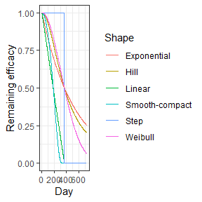

Decay function shapes (L=365 days, kappa=2 where applicable).

```r
itn_p = get_ITN_params("Interceptor G2", "Kibondo")
```

```
#> ITN parameterisation loaded: Interceptor G2 (Kibondo)
#> Mode: standard
#> Reference: Kibondo et al.
#> Efficacy (unwashed):
#> PostPrandial  PrePrandial   Deterrency
#>         0.52         0.44         0.71
#> Insecticide decay, linear time to zero (years; omitted = no decay):
#> PostPrandial  PrePrandial   Deterrency
#>         31.2         66.0        -71.0
```

```r
my_interv = build_intervention(
    efficacy             = itn_p$efficacy,
    halflife_insecticide = itn_p$halflife_insecticide,
    mode                 = itn_p$mode,
    halflife_attrition =  3*365, shape_attrition = 2, decay_attrition = "weibull",
    duration_years = 3, model_p = model_p, name = itn_p$name
)
```

```
#> build_intervention: using standard (3-host) model with PrePrandial.
```

With insecticide decay (the default `insecticide_decay = TRUE`), the object also contains, for each efficacy component, the single Weibull decay that best approximates attrition × insecticide decay (as used for OpenMalaria GVI parameterisations). The model itself uses the exact decay:

```r
my_interv[[1]]$fitted_decay
```

```
#>      component        L    kappa         a         rmse
#> 1   Deterrency 1123.921 2.111899 1.0000000 0.0014470423
#> 2  PrePrandial 1062.347 1.922713 0.9972752 0.0006693282
#> 3 PostPrandial 1024.311 1.848518 0.9946168 0.0013085623
```

Set `insecticide_decay = FALSE` to ignore the insecticide decay and keep the unwashed efficacy throughout (only attrition decays):

```r
my_interv_nodecay = build_intervention(
    efficacy = itn_p$efficacy, halflife_insecticide = itn_p$halflife_insecticide,
    mode = itn_p$mode, insecticide_decay = FALSE,
    halflife_attrition = 3*365, shape_attrition = 2, decay_attrition = "weibull",
    duration_years = 3, model_p = model_p, name = itn_p$name
)
```

Custom efficacy values can also be supplied directly:

```r
my_interv_custom = build_intervention(
    efficacy = c(Deterrency = 0.50, PrePrandial = 0.60, PostPrandial = 0.70),
    halflife_attrition = 3*365, shape_attrition = 2, decay_attrition = "weibull",
    duration_years = 3, model_p = model_p, name = "Custom ITN"
)
```

**Dummy-host model** — host-seeking killing replaces pre-prandial; deterrency and post-prandial killing remain. Use `mode = "dummy_host"` to load the corresponding parameters from the database:

```r
itn_dh_p = get_ITN_params("Interceptor G2", "Kibondo", mode = "dummy_host")
```

```
#> ITN parameterisation loaded: Interceptor G2 (Kibondo)
#> Mode: dummy_host
#> Reference: Kibondo et al.
#> Efficacy (unwashed):
#>       PostPrandial         Deterrency HostSeekingKilling
#>               0.52               0.71               3.58
#> Insecticide decay, linear time to zero (years; omitted = no decay):
#>       PostPrandial         Deterrency HostSeekingKilling
#>             31.200            -71.000             63.176
```

```r
my_interv_dh = build_intervention(
    efficacy             = itn_dh_p$efficacy,
    halflife_insecticide = itn_dh_p$halflife_insecticide,
    mode                 = itn_dh_p$mode,
    halflife_attrition = 180, shape_attrition = 2, decay_attrition = "weibull",
    duration_years = 3, model_p = model_p, name = itn_dh_p$name
)
```

```
#> build_intervention: using dummy-host (4-host) model with HostSeekingKilling.
```

```r
# effects matrices now have 4 columns (protected humans, unprotected, animals, dummy host)
ncol(my_interv_dh[[1]]$effects$alphai)
```

```
#> [1] 4
```

**Per-component decay** — each efficacy component can decay independently via the `component_decay` argument (optional: when absent, a component stays at its initial value throughout and only the attrition decay applies):

```r
my_interv_compdecay = build_intervention(
    efficacy = c(Deterrency = 0.50, PrePrandial = 0.60, PostPrandial = 0.70),
    halflife_attrition = 365, shape_attrition = 2, decay_attrition = "weibull",
    duration_years = 3, model_p = model_p,
    name = "ITN (per-component decay)",
    component_decay = list(                           # optional per-component decay
        Deterrency  = list(decay = "hill",   L = 90,  kappa = 3),   # fast
        PrePrandial = list(decay = "linear", L = 730, kappa = NULL)  # slow
    )
)
```

```
#> build_intervention: using standard (3-host) model with PrePrandial.
```

### Step 6: Calculate impact

Pass the intervention object to `calculate_impact()`, supplying the effective coverage. The exposure-weighted coverage can be derived from `calculate_exposure()`:

```r
# Effective in-bed coverage = deployment coverage × fraction of exposure while in bed
pop_coverage = 0.8
eff_coverage = pop_coverage * exposure$Exposure_Indoor_whileinbed
cat("Effective coverage:", round(eff_coverage, 3), "\n")
```

```
#> Effective coverage: 0.739
```

```r
coverages = seq(0, 1, by = 0.1)

impacts = calculate_impact(
    interventions_vec = my_interv,
    coverage_vec      = coverages,
    model_p           = model_p
)
```

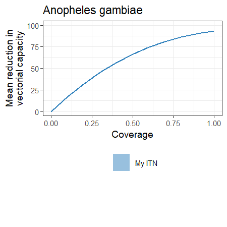

Vectorial capacity reduction for the ITN scenario.

```r
plot_tab = data.frame(
    intervention_name     = "My ITN",
    intervention_coverage = coverages,
    intervention_impact   = impacts$interventions_vec[[1]]$effects$avg_impact
)
plot_impact_var("Anopheles gambiae", plot_tab)
```

`calculate_combined_impact()` handles two simultaneously deployed interventions. Effects combine multiplicatively; dummy-host interventions are also supported, with host-seeking killing adding up for people covered by both:

```r
interv_ITN = build_intervention(
    efficacy = c(Deterrency = 0.5, PrePrandial = 0.6, PostPrandial = 0.7),
    halflife_attrition = 180, shape_attrition = 2, decay_attrition = "weibull",
    duration_years = 1, model_p = model_p, name = "ITN"
)
```

```
#> build_intervention: using standard (3-host) model with PrePrandial.
```

```r
interv_IRS = build_intervention(
    efficacy = c(Deterrency = 0.0, PrePrandial = 0.3, PostPrandial = 0.8),
    halflife_attrition = 180, shape_attrition = 2, decay_attrition = "weibull",
    duration_years = 1, model_p = model_p, name = "IRS"
)
```

```
#> build_intervention: using standard (3-host) model with PrePrandial.
```

```r
combined_impact = calculate_combined_impact(
    combination_name  = "ITN + IRS",
    intervention1     = interv_ITN[[1]], intervention2 = interv_IRS[[1]],
    cov_intervention1 = 0.8,            cov_intervention2 = 0.8,
    model_p = model_p
)
```

```
#> ITN + IRS: assigned coverages 0.04 0.16 0.16 0.64
```

```r
cat("Combined VC reduction:", round(combined_impact * 100, 1), "%\n")
```

```
#> Combined VC reduction: 84.2 %
```

### Step 7: Vectorised analysis and parameter uncertainty

`run_interventions()` sweeps a data frame of scenarios in a single call and optionally propagates uncertainty from four sources. Required columns: `name`, `deterrency`, `preprandial`, `postprandial`, `halflife_attrition` (attrition half-life in days), `shape_attrition`, `decay_attrition`. Use `duration_years` to set the evaluation window.

The output is a `data.table` with **all input columns from `param_sets`** joined to the computed outputs (`coverage`, `avg_vc`, `avg_impact`), giving a self-contained database ready for downstream analysis without any manual re-joining.

#### Scenario sweep

```r
param_sets = data.frame(
    name         = c("Low efficacy", "Medium efficacy", "High efficacy"),
    deterrency   = c(0.20, 0.4, 0.5),
    preprandial  = c(0.25, 0.55, 0.80),
    postprandial = c(0.20, 0.50, 0.75),
    halflife_attrition = 180, shape_attrition = 2, decay_attrition = "weibull",
    stringsAsFactors = FALSE
)

results = run_interventions(
    param_sets   = param_sets,
    model_p      = model_p,
    coverage_vec = seq(0, 1, by = 0.2),
    duration_years = 3
)
```

```
#> run_interventions: using standard (3-host) model.
```

```r
# All param_sets columns (deterrency, preprandial, …) are present alongside outputs
head(results)
```

```
#>            name deterrency preprandial postprandial halflife_attrition
#>          <char>      <num>       <num>        <num>              <num>
#> 1: Low efficacy        0.2        0.25          0.2                180
#> 2: Low efficacy        0.2        0.25          0.2                180
#> 3: Low efficacy        0.2        0.25          0.2                180
#> 4: Low efficacy        0.2        0.25          0.2                180
#> 5: Low efficacy        0.2        0.25          0.2                180
#> 6: Low efficacy        0.2        0.25          0.2                180
#>    shape_attrition decay_attrition coverage    avg_vc avg_impact
#>              <num>          <char>    <num>     <num>      <num>
#> 1:               2         weibull      0.0 0.7849775 0.00000000
#> 2:               2         weibull      0.2 0.7316430 0.06794398
#> 3:               2         weibull      0.4 0.6912305 0.11942625
#> 4:               2         weibull      0.6 0.6603310 0.15878985
#> 5:               2         weibull      0.8 0.6364877 0.18916432
#> 6:               2         weibull      1.0 0.6179056 0.21283655
```

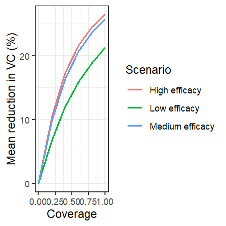

Vectorial capacity reduction for three efficacy scenarios.

```r
ggplot(results, aes(x=coverage, y=avg_impact*100, colour=name, group=name)) +
    geom_line(size=0.8) + theme_bw() +
    labs(x="Coverage", y="Mean reduction in VC (%)", colour="Scenario")
```

#### Choosing a model: standard vs dummy-host

The package implements two **mutually exclusive** model structures. Choose one before building your `param_sets` — do not mix columns from both in the same data frame.

|  | Standard (3-host) | Dummy-host (4-host) |
| --- | --- | --- |
| Pre-prandial killing | `preprandial` | — (set to 0, unused) |
| Host-seeking killing | — | `host_seeking_killing` |
| `PrePrandial` in `build_intervention` | yes | no |
| `HostSeekingKilling` in `build_intervention` | no | yes |
| Typical data source | WHO tunnel / cone test | Experimental hut with dummy host |

**Standard model** — mosquitoes can be killed while feeding (`preprandial`):

```r
standard_ps = data.frame(
    name         = "Standard ITN",
    deterrency   = 0.55,
    preprandial  = 0.28,
    postprandial = 0.24,
    halflife_attrition = 180, shape_attrition = 2, decay_attrition = "weibull",
    stringsAsFactors = FALSE
)
coverage_vec = seq(0, 1, by = 0.2)
res_std = run_interventions(standard_ps, model_p, coverage_vec, duration_years = 3)
```

```
#> run_interventions: using standard (3-host) model.
```

```r
res_std[, c("name", "coverage", "avg_impact")]
```

```
#>            name coverage avg_impact
#>          <char>    <num>      <num>
#> 1: Standard ITN      0.0 0.00000000
#> 2: Standard ITN      0.2 0.06423253
#> 3: Standard ITN      0.4 0.11652589
#> 4: Standard ITN      0.6 0.15835395
#> 5: Standard ITN      0.8 0.19117699
#> 6: Standard ITN      1.0 0.21645110
```

**Dummy-host model** — mosquitoes are diverted to a fourth “dummy host” and killed while host-seeking. Replace `preprandial` with `host_seeking_killing` (`preprandial` must still be present but set to 0):

```r
dummyhost_ps = data.frame(
    name                 = "Dummy-host ITN",
    deterrency           = 0.55,
    preprandial          = 0,      # required column; set to 0 in dummy-host mode
    postprandial         = 0.24,
    host_seeking_killing = 1.10,   # rate multiplier; values > 1 are valid
    halflife_attrition   = 180, shape_attrition = 2, decay_attrition = "weibull",
    stringsAsFactors     = FALSE
)
res_dh = run_interventions(dummyhost_ps, model_p, coverage_vec, duration_years = 3)
```

```
#> run_interventions: using dummy-host (4-host) model (host_seeking_killing column detected). Set preprandial = 0 for all rows.
```

```r
res_dh[, c("name", "coverage", "avg_impact")]
```

```
#>              name coverage avg_impact
#>            <char>    <num>      <num>
#> 1: Dummy-host ITN      0.0  0.0000000
#> 2: Dummy-host ITN      0.2  0.1107059
#> 3: Dummy-host ITN      0.4  0.1762596
#> 4: Dummy-host ITN      0.6  0.2177316
#> 5: Dummy-host ITN      0.8  0.2455877
#> 6: Dummy-host ITN      1.0  0.2653816
```

To add insecticide decay on `host_seeking_killing`, use the `_hsk` decay columns (`halflife_hsk` for a simple linear decay in years, or `decay_hsk` + `L_hsk` + `kappa_hsk` for a general decay shape):

```r
# Dummy-host model with Weibull decay on host-seeking killing (half-life 90 days)
dummyhost_decay_ps = data.frame(
    name                 = "Dummy-host ITN (with HSK decay)",
    deterrency           = 0.55,
    preprandial          = 0,
    postprandial         = 0.24,
    host_seeking_killing = 1.10,
    halflife_attrition   = 180, shape_attrition = 2, decay_attrition = "weibull",
    decay_hsk = "weibull", L_hsk = 90, kappa_hsk = 2,   # HSK decays faster than attrition
    stringsAsFactors     = FALSE
)
res_dh_decay = run_interventions(dummyhost_decay_ps, model_p, coverage_vec, duration_years = 3)
```

```
#> run_interventions: using dummy-host (4-host) model (host_seeking_killing column detected). Set preprandial = 0 for all rows.
```

```r
res_dh_decay[, c("name", "coverage", "avg_impact")]
```

```
#>                               name coverage avg_impact
#>                             <char>    <num>      <num>
#> 1: Dummy-host ITN (with HSK decay)      0.0 0.00000000
#> 2: Dummy-host ITN (with HSK decay)      0.2 0.07303494
#> 3: Dummy-host ITN (with HSK decay)      0.4 0.12092190
#> 4: Dummy-host ITN (with HSK decay)      0.6 0.15450577
#> 5: Dummy-host ITN (with HSK decay)      0.8 0.17938116
#> 6: Dummy-host ITN (with HSK decay)      1.0 0.19865247
```

#### Per-component insecticide decay

Each efficacy component (deterrency, pre-prandial, post-prandial, host-seeking killing) can have its own decay shape and half-life, independent of the physical attrition decay. Add optional columns `decay_det`/`L_det`/`kappa_det`, `decay_pre`/`L_pre`/`kappa_pre`, `decay_post`/`L_post`/`kappa_post` (any omitted column falls back to no per-component decay):

```r
# Three scenarios with identical initial efficacy but different component decays
comp_decay_ps = data.frame(
    name         = c("No comp. decay", "Fast deterrency", "Differential decay"),
    deterrency   = 0.55,
    preprandial  = 0.45,
    postprandial = 0.40,
    halflife_attrition = 365, shape_attrition = 2, decay_attrition = "weibull",
    # Scenario 2: deterrency decays fast (Weibull, half-life 60 d, shape 3)
    # Scenario 3: deterrency fast (Weibull), pre-prandial slow (linear, 2 yr), post-prandial medium (linear, 1 yr)
    decay_det  = c(NA,        "weibull", "weibull"),
    L_det      = c(NA,         60,        60),
    kappa_det  = c(NA,          3,         3),
    decay_pre  = c(NA,        NA,        "linear"),
    L_pre      = c(NA,        NA,         730),
    kappa_pre  = c(NA,        NA,         NA),
    decay_post = c(NA,        NA,        "linear"),
    L_post     = c(NA,        NA,         365),
    kappa_post = c(NA,        NA,         NA),
    stringsAsFactors = FALSE
)

comp_results = run_interventions(
    param_sets   = comp_decay_ps,
    model_p      = model_p,
    coverage_vec = seq(0, 1, by = 0.1),
    duration_years = 3
)
```

```
#> run_interventions: using standard (3-host) model.
```

```r
head(comp_results[, c("name", "coverage", "avg_impact")])
```

```
#>              name coverage avg_impact
#>            <char>    <num>      <num>
#> 1: No comp. decay      0.0 0.00000000
#> 2: No comp. decay      0.1 0.08690699
#> 3: No comp. decay      0.2 0.16226693
#> 4: No comp. decay      0.3 0.22738109
#> 5: No comp. decay      0.4 0.28343412
#> 6: No comp. decay      0.5 0.33150716
```

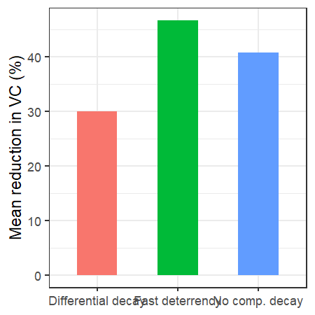

Effect of per-component insecticide decay on average impact at 70% coverage.

```r
# Compare with a tolerance: seq() does not produce exactly 0.7
ggplot(comp_results[abs(comp_results$coverage - 0.7) < 1e-8, ],
       aes(x = name, y = avg_impact * 100, fill = name)) +
    geom_col(width = 0.5) + theme_bw() +
    labs(x = NULL, y = "Mean reduction in VC (%)", fill = NULL) +
    theme(legend.position = "none")
```

#### Parameter uncertainty

`run_interventions()` supports four **zipped** uncertainty sources — draw `d` uses entry `d` from each active source simultaneously. A `draw` column is added to the output. All active sources must supply the same `n_draw`.

[output not shown]

**Vector parameter uncertainty** — 200 draws of *An. gambiae* bionomics:

```r
set.seed(42)
n_draws  = 200
base_vec = gambiae_vec_p

vec_draws = data.frame(
    species_name = base_vec$species_name,
    M    = pmax(pmin(rnorm(n_draws, base_vec$M,  0.06), 0.999), 0.001),  # parous rate
    M.sd = base_vec$M.sd,
    Chi  = base_vec$Chi,                                                   # HBI
    A0   = pmax(pmin(rnorm(n_draws, base_vec$A0, 0.03), 0.999), 0.001),  # sac rate
    A0.sd=base_vec$A0.sd, zeta.3=base_vec$zeta.3, td=base_vec$td,
    tau=base_vec$tau, ts=base_vec$ts, to=base_vec$to,
    endophily=base_vec$endophily, endophily.sd=base_vec$endophily.sd,
    endophagy=base_vec$endophagy, endophagy.sd=base_vec$endophagy.sd,
    stringsAsFactors=FALSE
)

single_scenario = data.frame(
    name="Medium efficacy ITN", deterrency=0.45, preprandial=0.55,
    postprandial=0.50, halflife_attrition=180, shape_attrition=2,
    decay_attrition="weibull", stringsAsFactors=FALSE
)
coverage_grid = seq(0, 1, by=0.1)

uncertainty_results = run_interventions(
    param_sets=single_scenario, model_p=model_p, coverage_vec=coverage_grid,
    vec_param_sets=vec_draws, duration_years=3
)
```

```
#> run_interventions: using standard (3-host) model.
```

```r
# Each row carries both the intervention inputs and the draw-specific vector
# parameters (M, Chi, A0, …) alongside avg_vc, avg_impact, and draw.
head(uncertainty_results)
```

```
#>                   name deterrency preprandial postprandial halflife_attrition
#>                 <char>      <num>       <num>        <num>              <num>
#> 1: Medium efficacy ITN       0.45        0.55          0.5                180
#> 2: Medium efficacy ITN       0.45        0.55          0.5                180
#> 3: Medium efficacy ITN       0.45        0.55          0.5                180
#> 4: Medium efficacy ITN       0.45        0.55          0.5                180
#> 5: Medium efficacy ITN       0.45        0.55          0.5                180
#> 6: Medium efficacy ITN       0.45        0.55          0.5                180
#>    shape_attrition decay_attrition      species_name         M        M.sd
#>              <num>          <char>            <char>     <num>       <num>
#> 1:               2         weibull Anopheles gambiae 0.6956071 0.003573648
#> 2:               2         weibull Anopheles gambiae 0.6956071 0.003573648
#> 3:               2         weibull Anopheles gambiae 0.6956071 0.003573648
#> 4:               2         weibull Anopheles gambiae 0.6956071 0.003573648
#> 5:               2         weibull Anopheles gambiae 0.6956071 0.003573648
```

[output cut: 17 more lines]

```r
library(dplyr)
```

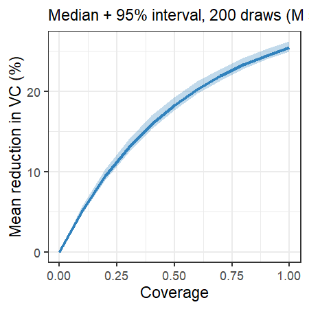

Uncertainty band (median + 95% interval) across 200 draws of vector parameters.

```r
unc_summary = uncertainty_results %>%
    group_by(coverage) %>%
    summarise(med=median(avg_impact), lo=quantile(avg_impact,0.025),
              hi=quantile(avg_impact,0.975), .groups="drop")

ggplot(unc_summary, aes(x=coverage)) +
    geom_ribbon(aes(ymin=lo*100, ymax=hi*100), alpha=0.3, fill="#3182bd") +
    geom_line(aes(y=med*100), colour="#3182bd", size=1) + theme_bw() +
    labs(x="Coverage", y="Mean reduction in VC (%)",
         subtitle="Median + 95% interval, 200 draws (M sd=0.06, A0 sd=0.03)")
```

```r
set.seed(7)
n_draws_interv = 50
interv_draws = data.frame(
    name         = "ITN",
    deterrency   = pmin(pmax(rnorm(n_draws_interv, 0.45, 0.08), 0), 1),
    preprandial  = pmin(pmax(rnorm(n_draws_interv, 0.55, 0.10), 0), 1),
    postprandial = pmin(pmax(rnorm(n_draws_interv, 0.50, 0.09), 0), 1),
    halflife_attrition = 180, shape_attrition = 2, decay_attrition = "weibull"
)

interv_unc_results = run_interventions(
    param_sets=single_scenario, model_p=model_p, coverage_vec=coverage_grid,
    interv_param_sets=interv_draws, duration_years=3
)
```

```
#> run_interventions: using standard (3-host) model.
```

```r
cat("Output rows:", nrow(interv_unc_results),
    "= 1 scenario x", length(coverage_grid), "coverage x", n_draws_interv, "draws\n")
```

```
#> Output rows: 550 = 1 scenario x 11 coverage x 50 draws
```

```r
# Each row carries the draw-specific input parameters (deterrency, preprandial, …)
# alongside avg_vc, avg_impact, and draw — no re-joining needed.
head(interv_unc_results)
```

```
#>      name deterrency preprandial postprandial halflife_attrition
#>    <char>      <num>       <num>        <num>              <num>
#> 1:    ITN  0.6329798   0.5237258    0.5467153                180
#> 2:    ITN  0.6329798   0.5237258    0.5467153                180
#> 3:    ITN  0.6329798   0.5237258    0.5467153                180
#> 4:    ITN  0.6329798   0.5237258    0.5467153                180
#> 5:    ITN  0.6329798   0.5237258    0.5467153                180
#> 6:    ITN  0.6329798   0.5237258    0.5467153                180
#>    shape_attrition decay_attrition coverage    avg_vc avg_impact  draw
#>              <num>          <char>    <num>     <num>      <num> <int>
#> 1:               2         weibull      0.0 0.7849775 0.00000000     1
#> 2:               2         weibull      0.1 0.7507697 0.04357803     1
#> 3:               2         weibull      0.2 0.7209917 0.08151292     1
#> 4:               2         weibull      0.3 0.6952071 0.11436040     1
#> 5:               2         weibull      0.4 0.6730055 0.14264354     1
#> 6:               2         weibull      0.5 0.6539992 0.16685611     1
```

Multiple uncertainty sources can be combined — all are zipped so `n_draw` must match across sources:

```r
set.seed(99)
n_draws_joint = 30
joint_results = run_interventions(
    param_sets=single_scenario, model_p=model_p, coverage_vec=coverage_grid,
    vec_param_sets    = vec_draws[seq_len(n_draws_joint), ],
    interv_param_sets = interv_draws[seq_len(n_draws_joint), ],
    duration_years=3
)
```

```
#> run_interventions: using standard (3-host) model.
```

```r
cat("Joint rows:", nrow(joint_results),
    "= 1 x", length(coverage_grid), "x", n_draws_joint, "\n")
```

```
#> Joint rows: 330 = 1 x 11 x 30
```

## Generating entomology XML snippets for OpenMalaria

`get_OM_ento_snippet()` creates the `<mosq>` and `<nonHumanHosts>` XML tags:

```r
xml_snippets = get_OM_ento_snippet(gambiae_vec_p, host_p)
print(xml_snippets)
```

```
#> $mosq_snippet
#> <mosq minInfectedThreshold="0.01">
#>   <mosqRestDuration value="2"/>
#>   <extrinsicIncubationPeriod value="10"/>
#>   <mosqLaidEggsSameDayProportion value="0.628132947686364"/>
#>   <mosqSeekingDuration value="3"/>
#>   <mosqSurvivalFeedingCycleProbability value="0.613349555351491"/>
#>   <availability/>
#>   <mosqProbBiting mean="0.95" variance="0"/>
#>   <mosqProbFindRestSite mean="0.95" variance="0"/>
#>   <mosqProbResting mean="0.99" variance="0"/>
#>   <mosqProbOvipositing mean="0.88"/>
#>   <mosqHumanBloodIndex mean="0.851050377416792"/>
#> </mosq>
#>
#> $nonHumanHosts_snippet
#> <nonHumanHosts name="unprotectedAnimals">
#>   <mosqRelativeEntoAvailability value="1"/>
#>   <mosqProbBiting value="0.95"/>
#>   <mosqProbFindRestSite value="0.95"/>
#>   <mosqProbResting value="0.99"/>
#> </nonHumanHosts>
```

## References

Briët, Olivier JT, Daniel E Impoinvil, Nakul Chitnis, Emilie Pothin, Jean Frantz Lemoine, Joseph Frederic, and Thomas A Smith. 2019. “Models of Effectiveness of Interventions Against Malaria Transmitted by Anopheles Albimanus.” *Malaria Journal* 18 (1): 263.

Champagne, Clara et al. 2025. “Parameterisation of Vector Control Interventions for Entomological Models of Malaria Transmission.” *In Preparation*.

Chitnis, Nakul, Thomas Smith, and Richard Steketee. 2008. “A Mathematical Model for the Dynamics of Malaria in Mosquitoes Feeding on a Heterogeneous Host Population.” *Journal of Biological Dynamics* 2 (3): 259–85. https://doi.org/10.1080/17513750701769857.

Lemant, Jeanne, Barnabas Zogo, Thomas A Smith, Clara Champagne, Monica Golumbeanu, and Emilie Pothin. 2026. “Estimating the Variability of Anopheles Bionomics and Its Impact on Malaria Transmission with a Hierarchical Bayesian Model.” *bioRxiv*. https://doi.org/10.64898/2026.03.24.713291.

Massey, N Claire, Gala Garrod, Antoinette Wiebe, Andrew J Henry, Zhi Huang, Catherine L Moyes, and Marianne E Sinka. 2016. “A global bionomic database for the dominant vectors of human malaria.” *Scientific Data* 3 (1): 160014. https://doi.org/10.1038/sdata.2016.14.

Sherrard-Smith, Ellie, Janetta E. Skarp, Andrew D. Beale, Christen Fornadel, Laura C. Norris, Sarah J. Moore, Selam Mihreteab, et al. 2019. “Mosquito Feeding Behavior and How It Influences Residual Malaria Transmission Across Africa.” *Proceedings of the National Academy of Sciences* 116 (30): 15086–95. https://doi.org/10.1073/pnas.1820646116.